# Lab11

Spicy Bois

11/4/2019

# Lab 11

```r
data <- babynames
babies2018 <- read.csv(file = "yob2018.txt", header= FALSE)
colnames(babies2018) <- c("name", "sex","n")
babies2018$year <- rep(2018, nrow(babies2018))
babies2018$prop = babies2018$n / sum(babies2018$n)

totalbabies <- full_join(babynames, babies2018)
```

## Ariel and Rachel Team Plot

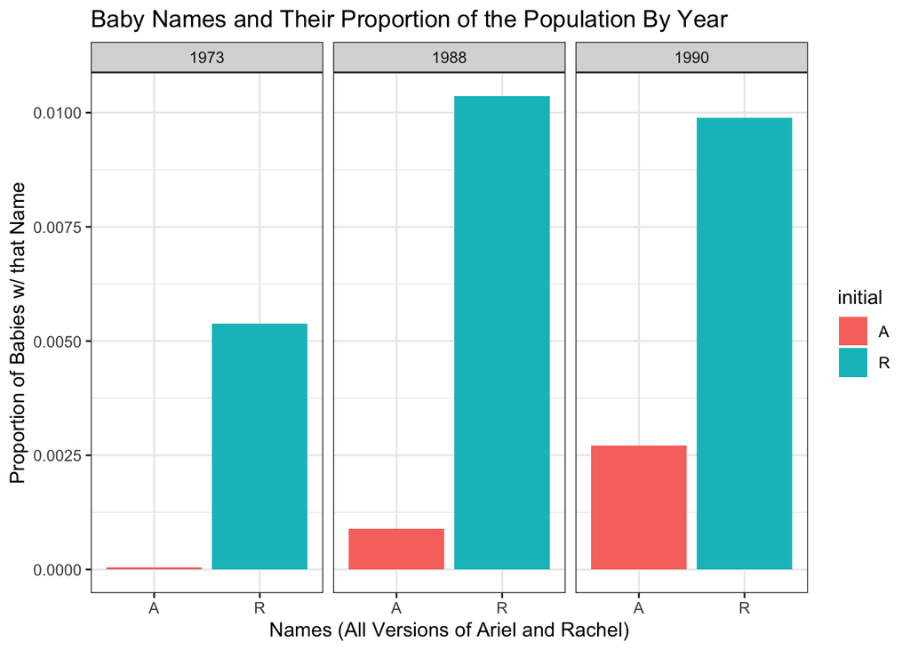

```r
data <- totalbabies

findName <- data %>%
  filter(str_detect(name, "^A[r]+[iyea][ea][l]+[ea]*$") | (str_detect(name, "^R[ae][aey]?[ch]+[aey]+[l]+e*$"))) %>%
  filter(year %in% list(1973, 1988, 1990)) %>%
  filter(sex == 'F')

findRachel <- data %>%
  filter(str_detect(name, "^R[ae][aey]?[ch]+[aey]+[l]+e*$")) %>%
  filter(year %in% list(1973, 1988, 1990)) %>%
  filter(sex == 'F')

names <- findName %>%
  group_by(year, initial = str_sub(name, 1, 1), prop) %>%
  summarize(variants = n())

ggplot(data = names, mapping = aes(x = initial, y = prop, fill = initial))+
  geom_col()+
  facet_wrap(~year)+
  labs(title = "Baby Names and Their Proportion of the Population By Year", x = "Names (All Versions of Ariel and Rachel)", y = "Proportion of Babies w/ that Name")+
  theme_bw()
```

## The Little Mermaid Effect

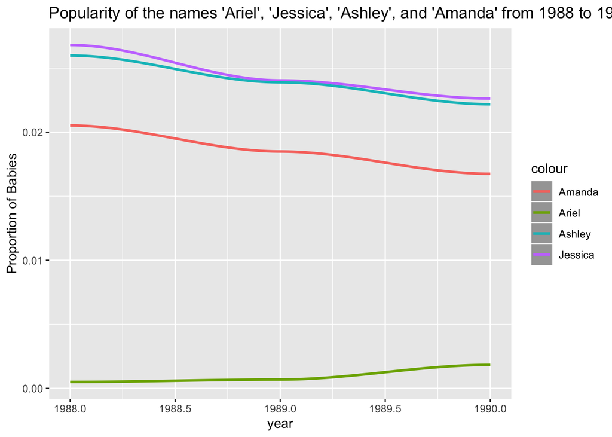

```r
data <- totalbabies

Ariel <- data %>%
  filter(str_detect(name, "^A[r]+[iyea][ea][l]+$")) %>%
  filter(sex == 'F') %>%
  filter(year >= 1988 & year <= 1990) %>%
  group_by(year, initial = str_sub(name, 1, 1)) %>%
  summarise(prop = sum(prop))

Jessica <- data %>%
  filter(str_detect(name, "^Jessica$")) %>%
  filter(sex == 'F') %>%
  filter(year >= 1988 & year <= 1990)

Ashley <- data %>%
  filter(str_detect(name, "^Ashley$")) %>%
  filter(sex == 'F') %>%
  filter(year >= 1988 & year <= 1990)

Amanda <- data %>%
  filter(str_detect(name, "^Amanda$")) %>%
  filter(sex == 'F') %>%
  filter(year >= 1988 & year <= 1990)

ggplot()+
  geom_smooth(data = Ariel, mapping = aes(x = year, y = prop, color="Ariel")) +
  geom_smooth(data = Jessica, mapping = aes(x = year, y = prop, color="Jessica"))+
  geom_smooth(data = Ashley, mapping = aes(x = year, y = prop, color="Ashley")) +
  geom_smooth(data = Amanda, mapping = aes(x = year, y = prop, color="Amanda")) +
  labs(title = "Popularity of the names 'Ariel', 'Jessica', 'Ashley', and 'Amanda' from 1988 to 1990", x = "year", y = "Proportion of Babies")
```

To show the effects that the Little Mermaid had on female names from 1988 to 1990, the graph above compares the proportions of all the versions of the name “Ariel” to the top three female baby names of 1988, “Jessica”, “Ashley”, and “Amanda”. Doing so, it become clear that while Ariel may not have been as directly popular as any of those names during this time period, there was a significant increase to females named “Ariel” over the time span, where as the proportion for all three of the most popular female names from 1988 actually dropped over the two year period.

## Jack Braglia Individual Graphs

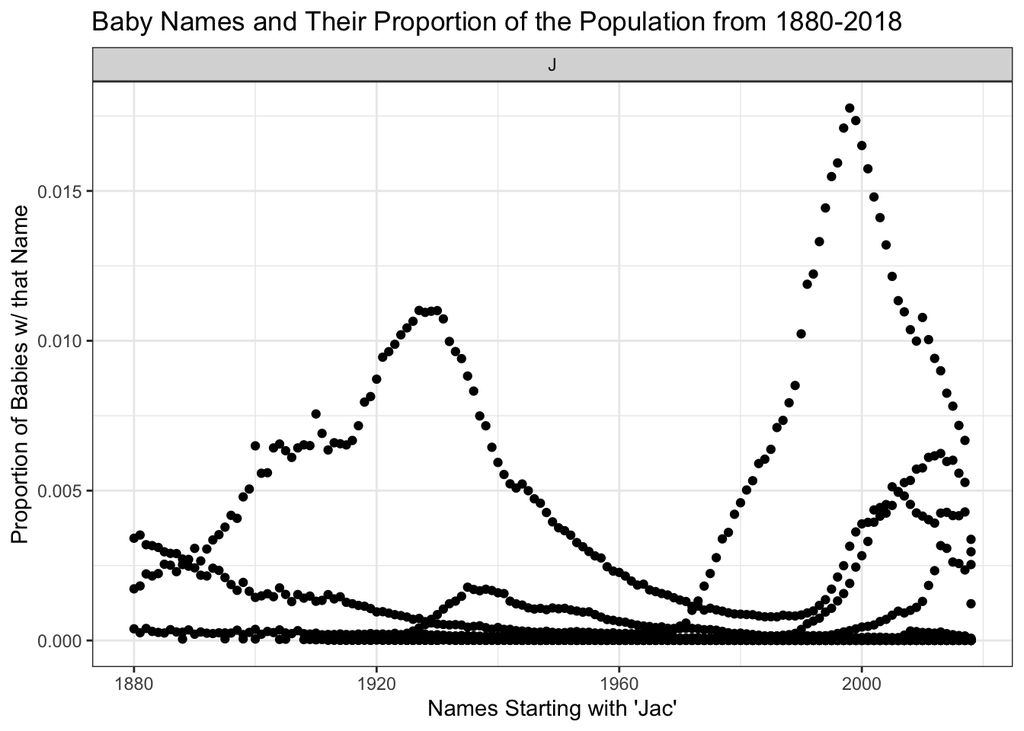

```r
data <- totalbabies

findMyName <- data %>%
  filter(str_detect(name, "^Jac")) %>%
  filter(sex == 'M')

findJack <- data %>%
  filter(str_detect(name, "^Jack$")) %>%
  filter(sex == 'M')

findJackAlive <- data %>%
  filter(str_detect(name, "^Jack$")) %>%
  filter(sex == 'M') %>%
  filter(year >= 1998)

mynames <- findMyName %>%
  group_by(year, initial = str_sub(name, 1, 1), prop) %>%
  summarize(variants = n())

myJack <- findJack %>%
  group_by(year, initial = str_sub(name, 1, 1), prop) %>%
  summarize(variants = n())

myJackAlive <- findJackAlive %>%
  group_by(year, initial = str_sub(name, 1, 1), prop) %>%
  summarize(variants = n())

ggplot(data = mynames, mapping = aes(x = year, y = prop))+
  facet_wrap(~initial)+
  geom_point()+
  labs(title = "Baby Names and Their Proportion of the Population from 1880-2018", x = "Names Starting with 'Jac'", y = "Proportion of Babies w/ that Name")+
  theme_bw()
```

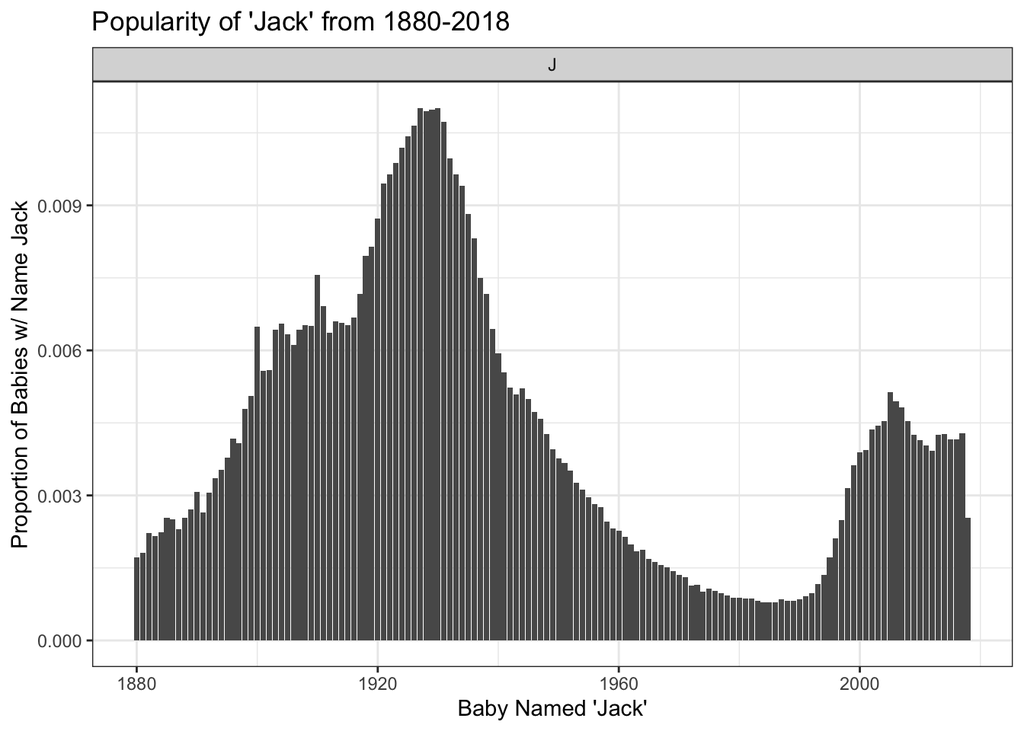

```r
ggplot(data = myJack, mapping = aes(x = year, y = prop))+
  facet_wrap(~initial)+
  geom_col()+
  labs(title = "Popularity of 'Jack' from 1880-2018", x = "Baby Named 'Jack'", y = "Proportion of Babies w/ Name Jack")+
  theme_bw()
```

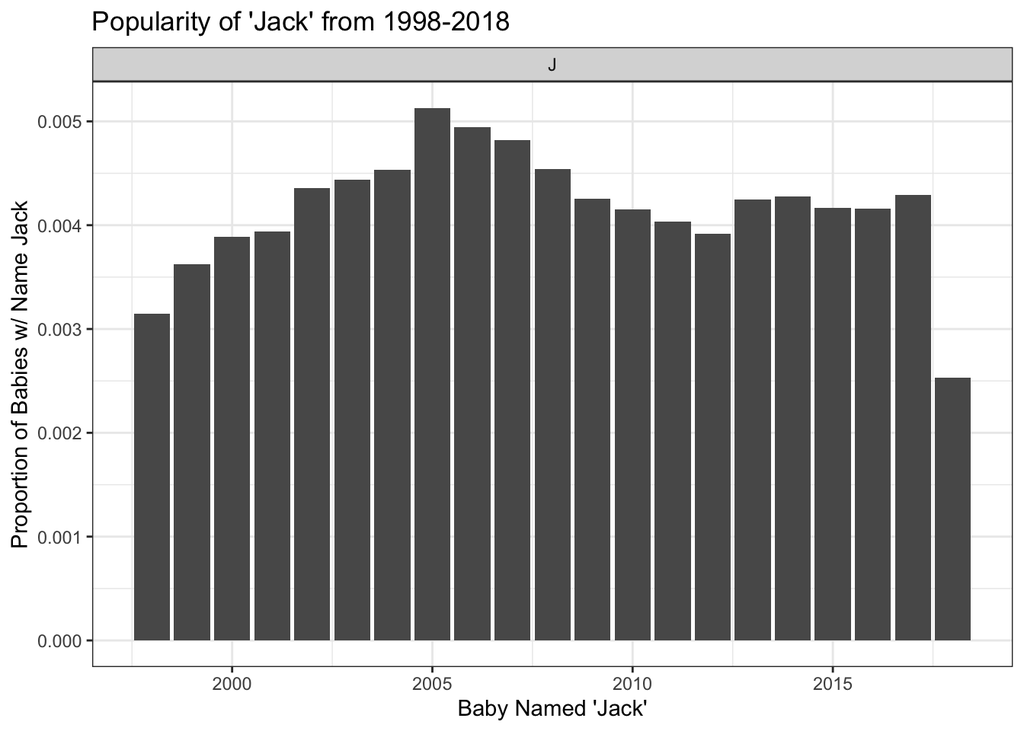

```r
ggplot(data = myJackAlive, mapping = aes(x = year, y = prop))+
  facet_wrap(~initial)+
  geom_col()+
  labs(title = "Popularity of 'Jack' from 1998-2018", x = "Baby Named 'Jack'", y = "Proportion of Babies w/ Name Jack")+
  theme_bw()
```

```r
goodnames <- data %>%
  filter(prop <= .001) %>%
  filter(prop >= .0005) %>%
  filter(year >= 2010) %>%
  filter(sex == 'M')

findDelilah <- data %>%
  filter(str_detect(name, "^Delilah$")) %>%
  filter(year >= 2010) %>%
  filter(sex == 'F')

findZion <- data %>%
  filter(str_detect(name, "^Zion$")) %>%
  filter(year >= 2010) %>%
  filter(sex == 'M')

findDelilah
```

```
## # A tibble: 9 x 5
##    year sex   name        n     prop
##   <dbl> <chr> <chr>   <int>    <dbl>
## 1  2010 F     Delilah  1667 0.000851
## 2  2011 F     Delilah  1827 0.000944
## 3  2012 F     Delilah  2091 0.00108
## 4  2013 F     Delilah  2341 0.00122
## 5  2014 F     Delilah  2509 0.00129
## 6  2015 F     Delilah  2728 0.00140
## 7  2016 F     Delilah  2725 0.00141
## 8  2017 F     Delilah  2873 0.00153
## 9  2018 F     Delilah  2982 0.000855
```

```r
findZion
```

```
## # A tibble: 9 x 5
##    year sex   name      n     prop
##   <dbl> <chr> <chr> <int>    <dbl>
## 1  2010 M     Zion   1525 0.000743
## 2  2011 M     Zion   1455 0.000717
## 3  2012 M     Zion   1530 0.000755
## 4  2013 M     Zion   1522 0.000755
## 5  2014 M     Zion   1479 0.000723
## 6  2015 M     Zion   1679 0.000824
## 7  2016 M     Zion   1834 0.000909
## 8  2017 M     Zion   1956 0.000996
## 9  2018 M     Zion   2153 0.000617
```

```r
goodnames
```

```
## # A tibble: 1,176 x 5
##     year sex   name         n     prop
##    <dbl> <chr> <chr>    <int>    <dbl>
##  1  2010 M     Josue     1996 0.000973
##  2  2010 M     Bradley   1994 0.000972
##  3  2010 M     Roman     1989 0.000969
##  4  2010 M     Axel      1971 0.000960
##  5  2010 M     Garrett   1959 0.000955
##  6  2010 M     Fernando  1952 0.000951
##  7  2010 M     Javier    1949 0.000950
##  8  2010 M     Leo       1942 0.000946
##  9  2010 M     Damien    1937 0.000944
## 10  2010 M     Peter     1931 0.000941
## # … with 1,166 more rows
```

**Jack Questions** How popular is your name now compared to when you were born? My name is less popular than it was when I was born according to the proportion the name was given to the population. The proportion of my name to the population in 1998 was .00314434. In 2018 it was .002533153. This is a difference of .000611187 between the year I was born and 2018.

**Jack Baby Recommendations** Female - Delilah Male - Zion

## Tyler Bischoff Individual Graphs

### Populatity of Names Starting With “TYL” Over Time

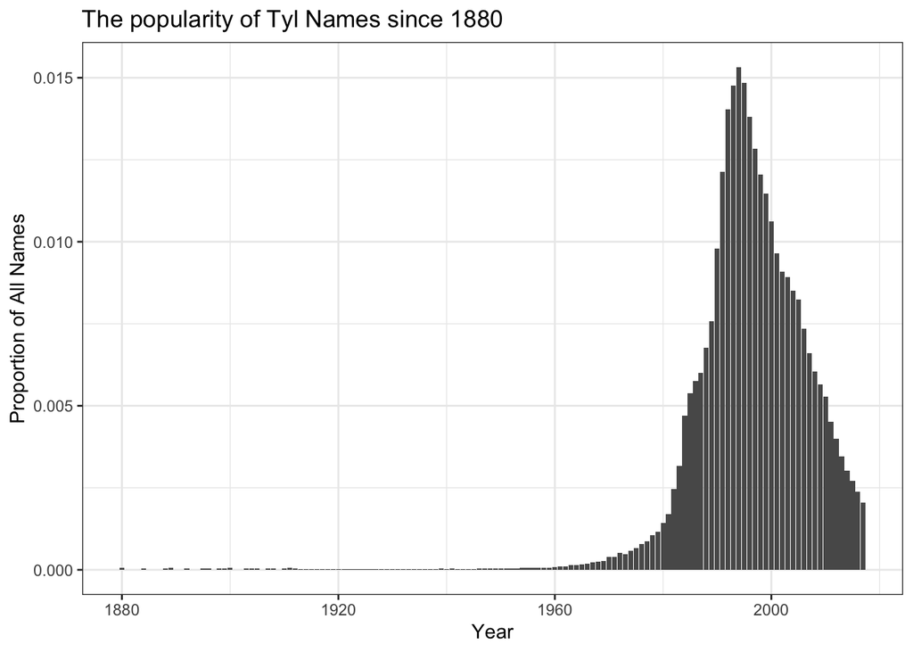

```r
findme <- babynames %>%
  filter(str_detect(name, "^Tyl")) %>%
  filter(sex == 'M') %>%
  group_by(year, initial = str_sub(name, 1, 3), prop) %>%
  summarise(yes = sum(n))

ggplot(data = findme) +
  geom_col(mapping = aes(x = year, y = prop)) +
  theme_bw() +
  labs(title = "The popularity of Tyl Names since 1880", x = "Year", y = "Proportion of All Names")
```

### Popularity of the Name Tyler Since 2000

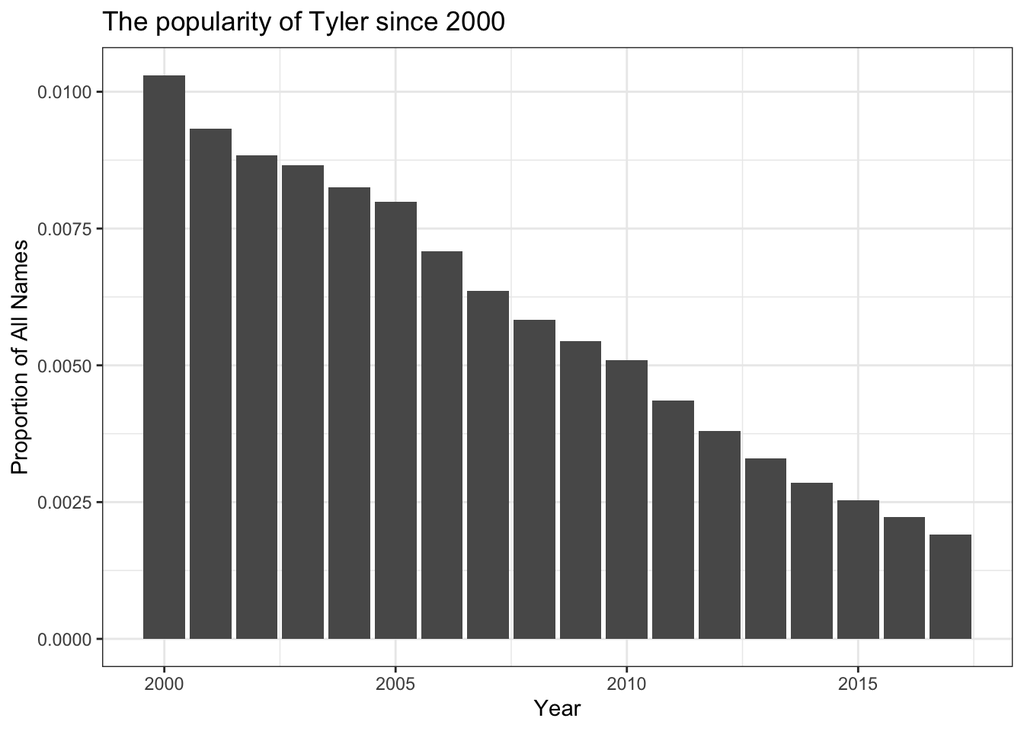

```r
mecurrent <- babynames %>%
  filter(str_detect(name, "^Tyler$")) %>%
  filter(year >=2000) %>%
  filter(sex == 'M') %>%
  group_by(year, initial = str_sub(name, 1, 5), prop) %>%
  summarise(yes = sum(n))

ggplot(data = mecurrent) +
  geom_col(mapping = aes(x = year, y = prop)) +
  theme_bw() +
  labs(title = "The popularity of Tyler since 2000", x = "Year", y = "Proportion of All Names")
```

### Popularity of the Name Tyler 18 Years Before 2000

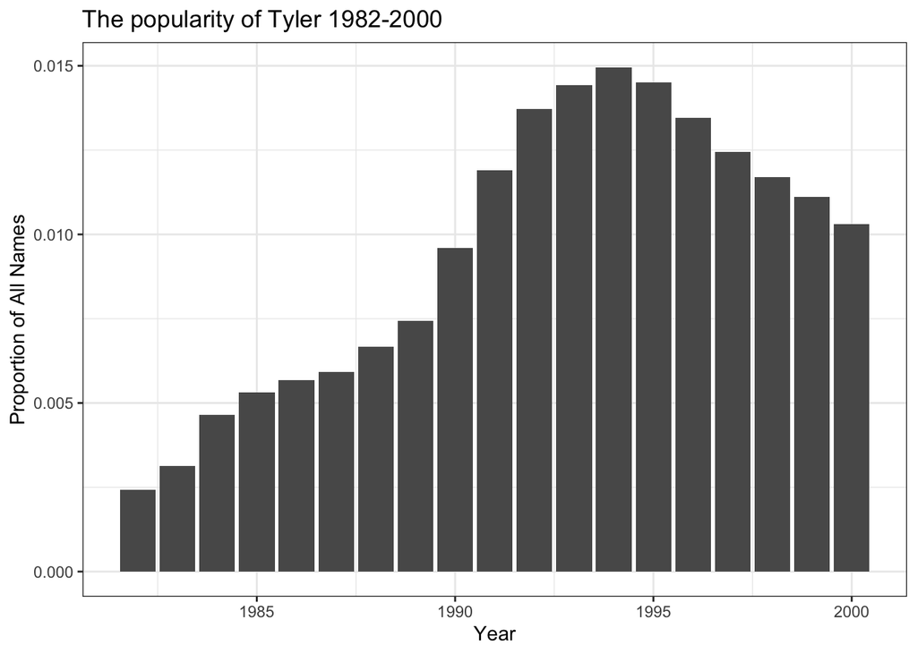

```r
meB4Current <- babynames %>%
  filter(str_detect(name, "^Tyler$")) %>%
  filter(year <=2000) %>%
  filter(year >= 1982) %>%
  filter(sex == 'M') %>%
  group_by(year, initial = str_sub(name, 1, 5), prop) %>%
  summarise(yes = sum(n))

ggplot(data = meB4Current) +
  geom_col(mapping = aes(x = year, y = prop)) +
  theme_bw() +
  labs(title = "The popularity of Tyler 1982-2000", x = "Year", y = "Proportion of All Names")
```

**Findings:** To find my name for the last 2 graphs I used the regular expresion of ^Tyler$ so that I would find my exact name. I did need the dollar sign at the end because there is a name Tylerjames which is not my name. There is also no other way to spell Tyler so finding my name was pretty simple. I found that my names since I was born has been on the decrease of popularity since. I also found that my name peaked in 1994 and has been going down in popularity since then.

### Tyler’s Trendy Name Picks

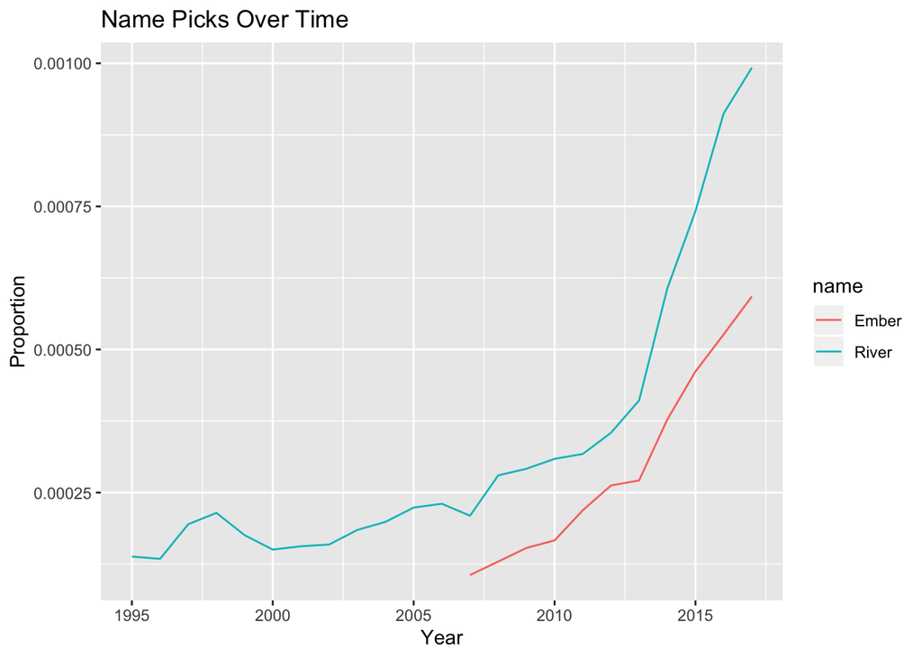

```r
goodnames <- babynames %>%
  filter(prop < 0.001 ) %>%
  filter(prop >= 0.0001)

maleName <- goodnames %>%
  filter(name == "River", sex == "M")

femaleName <- goodnames %>%
  filter(name == "Ember", sex == 'F')

namePick <- full_join(maleName, femaleName)

ggplot(data = namePick) +
  geom_line(mapping = aes(x = year, y = prop, color = name)) +
  labs(title = "Name Picks Over Time", x = "Year", y = "Proportion", size = 10)
```

**Findings:** I picked the two names Ember for a girl and River for a boy. These names, as shown in the graph. Have been on the increase, but aren’t super popular yet so these names are great picks. They will contiue to rise in popularity as shown by their current slope. That is why I picked the names Ember and River.

## Trent Collins Individual Graphs

### Plot of the poularity of the name “Trent” over time

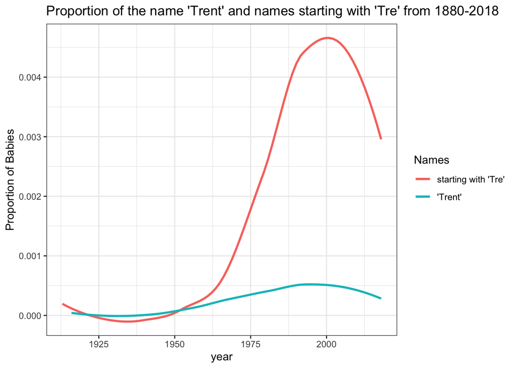

```r
data <- totalbabies

first3 <- data %>%
  filter(str_detect(name, "^Tre")) %>%
  filter(sex == 'M') %>%
  group_by(year, name = substr(name, 1, 3)) %>%
  summarise(prop = sum(prop))

justTrent <- data %>%
  filter(str_detect(name, "^Trent$")) %>%
  filter(sex == 'M') %>%
  group_by(year, name) %>%
  summarise(prop = sum(prop))

afterTrent <- data %>%
  filter(str_detect(name, "^Trent$")) %>%
  filter(sex == 'M') %>%
  filter(year >= 1998 & year <= 2018) %>%
  group_by(year, name) %>%
  summarise(prop = sum(prop))

beforeTrent <- data %>%
  filter(str_detect(name, "^Trent$")) %>%
  filter(sex == 'M') %>%
  filter(year >= 1978 & year <= 1998) %>%
  group_by(year, name) %>%
  summarise(prop = sum(prop))

ggplot()+
  geom_smooth(data = first3, mapping = aes(x = year, y = prop, color = "darkslategray1"),se = FALSE)+
  geom_smooth(data = justTrent, mapping = aes(x = year, y = prop, color = "orchid1"),se = FALSE)+
  labs(title = "Proportion of the name 'Trent' and names starting with 'Tre' from 1880-2018", x = "year", y = "Proportion of Babies")+
  scale_color_discrete(name = "Names", labels = c("starting with 'Tre'", "'Trent'")) +
  theme_bw()
```

### Polularity of the name “Trent” 20 years before and after 1998

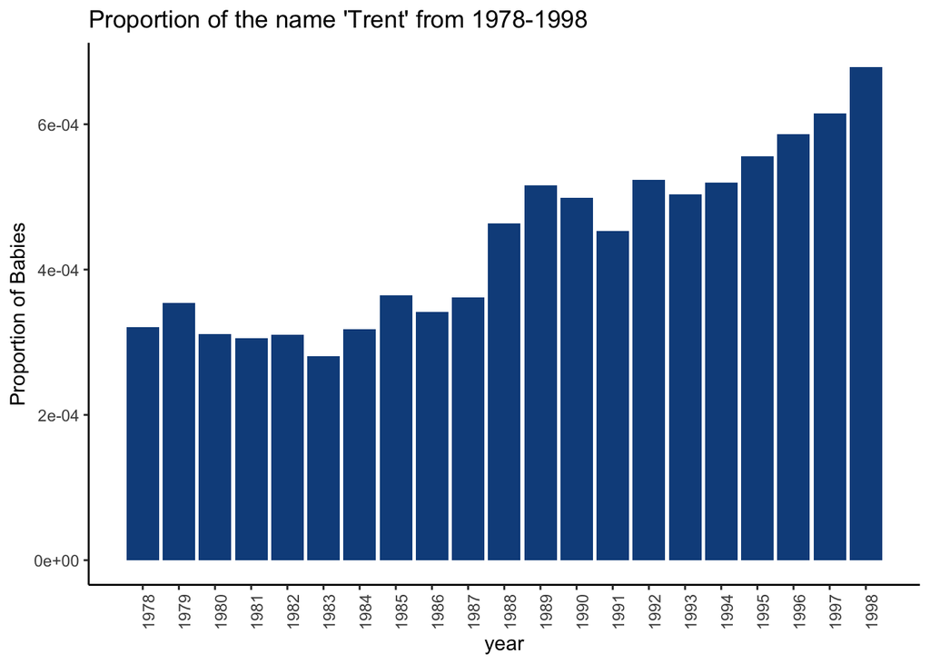

```r
ggplot()+
  geom_col(data = beforeTrent, mapping = aes(x = year, y = prop), fill = "dodgerblue4") +
  theme(axis.text.x = element_text(angle = 90))+
  labs(title = "Proportion of the name 'Trent' from 1978-1998", x = "year", y = "Proportion of Babies")+
  scale_x_continuous(breaks = c(1978,1979,1980,1981,1982,1983,1984,1985,1986,1987,1988,1989,1990,1991,1992,1993,1994,1995,1996,1997,1998)) +
  theme(axis.line = element_line(colour = "black"),
    panel.grid.major = element_blank(),
    panel.grid.minor = element_blank(),
    panel.border = element_blank(),
    panel.background = element_blank())
```

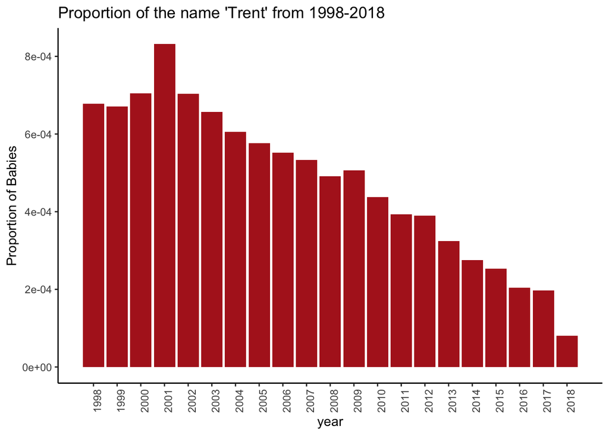

```r
ggplot()+
  geom_col(data = afterTrent, mapping = aes(x = year, y = prop), fill = "firebrick") +
  theme(axis.text.x = element_text(angle = 90))+
  labs(title = "Proportion of the name 'Trent' from 1998-2018", x = "year", y = "Proportion of Babies")+
  scale_x_continuous(breaks = c(1998,1999,2000,2001,2002,2003,2004,2005,2006,2007,2008,2009,2010,2011,2012,2013,2014,2015,2016,2017,2018)) +
  theme(axis.line = element_line(colour = "black"),
    panel.grid.major = element_blank(),
    panel.grid.minor = element_blank(),
    panel.border = element_blank(),
    panel.background = element_blank())
```

### Trent’s Recommendations for Trending Baby Names

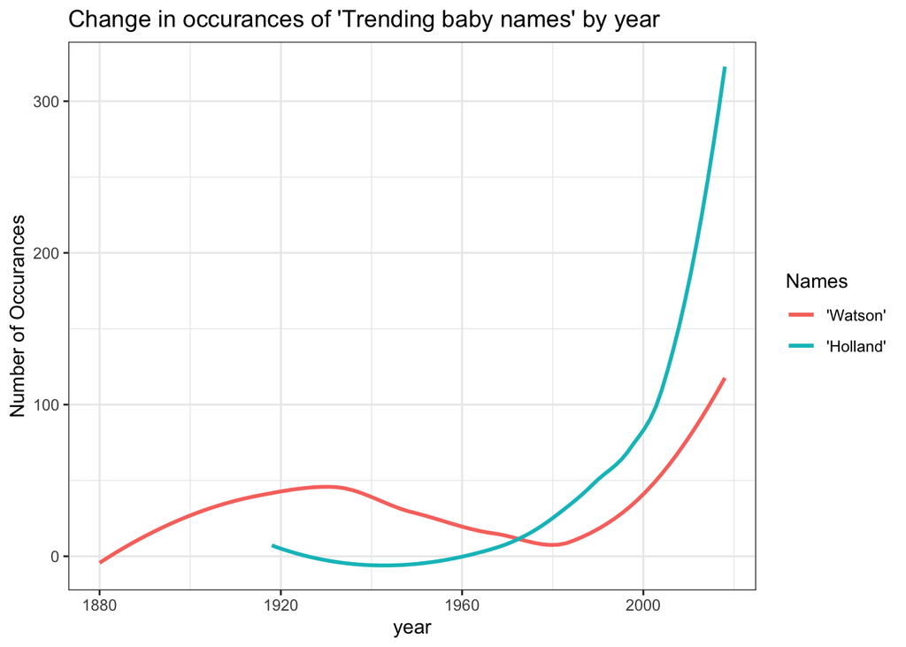

```r
data <- totalbabies

trendyM <- data %>%
  filter(str_detect(name, "^Watson$")) %>%
  filter(sex == 'M')

trendyF <- data %>%
  filter(str_detect(name, "^Holland$")) %>%
  filter(sex == 'F')

ggplot()+
  geom_smooth(data = trendyM, mapping = aes(x = year, y = n, color = "darkslategray1"),se = FALSE)+
  geom_smooth(data = trendyF, mapping = aes(x = year, y = n, color = "orchid1"),se = FALSE)+
  labs(title = "Change in occurances of 'Trending baby names' by year", x = "year", y = "Number of Occurances")+
  scale_color_discrete(name = "Names", labels = c("'Watson'", "'Holland'")) +
  theme_bw()
```

As clearly show in the graph, the names “Watson” for a male and “Holland” for a female are both examples of names that are not widely popular, but are starting to gain popularity over the past couple of years, and have occurrences on a positive upslope. Therefore, my name recommendations are: -Watson for male -Holland for female

## Logan Individual Graphs

### Populatity of Names Starting With “Log” Over Time

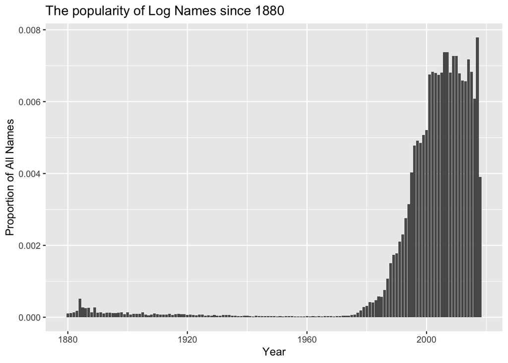

```r
#Logan, Logen, Loghen, Logann, Loganne
babynames_log <- totalbabies %>%
  filter(str_detect(name, "^Log"))
babynames_log_var <- babynames_log %>% group_by(year, initial = str_sub(name, 1, 3), prop) %>% summarise(count = sum(n))

ggplot(babynames_log_var,  aes(x = year, y = prop)) +
  geom_col() +
  labs(title = "The popularity of Log Names since 1880", x = "Year", y = "Proportion of All Names")
```

### Popularity of the Name Logan Since 2000

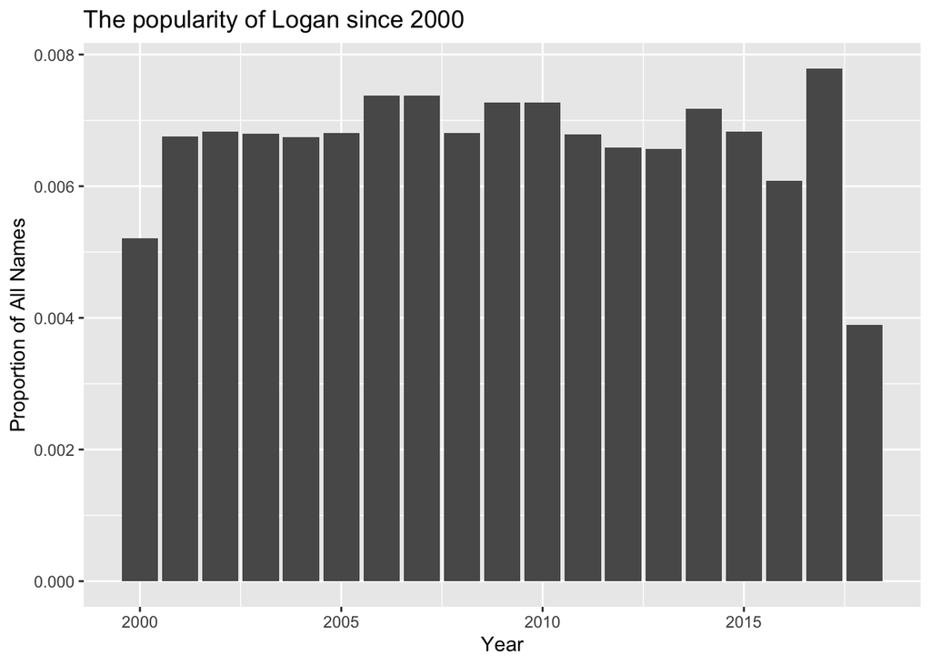

```r
babynames_logan <- totalbabies %>%
  filter(str_detect(name, "^Log+h*[a|e|i|o|u|y]h*n+e*$"))
babynames_logan_var <- babynames_logan %>% group_by(year, initial = str_sub(name, 1, 1), prop) %>% summarise(count = sum(n))

ggplot(data = babynames_logan_var %>% filter(year >= 2000), aes(x = year, y = prop)) +
  geom_col() +
  labs(title = "The popularity of Logan since 2000", x = "Year", y = "Proportion of All Names")
```

### Popularity of the Name Logan 18 Years Before 2000

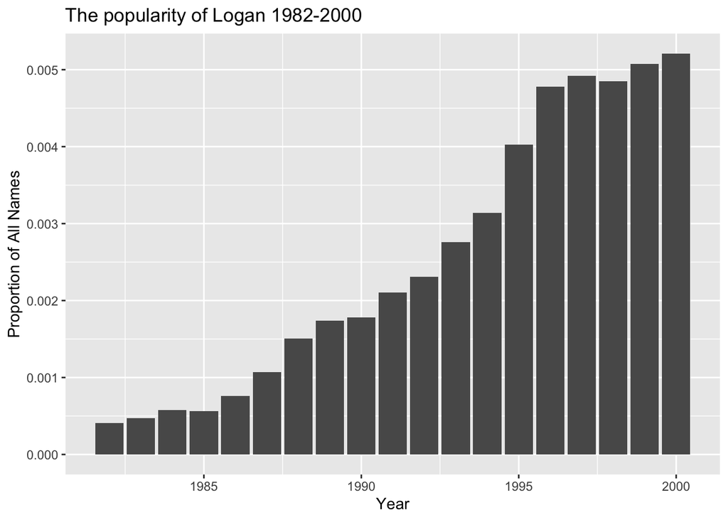

```r
ggplot(data = babynames_logan_var %>% filter(year <= 2000, year >= 1982), aes(x = year, y = prop)) +
  geom_col() +
  labs(title = "The popularity of Logan 1982-2000", x = "Year", y = "Proportion of All Names")
```

**Findings:** To find my name for the last 2 graphs I used the regular expresion of "^Log+h*[a|e|i|o|u|y]h*n+e*$" so that I would find my name and the different veriations of it. It seemed that most ways to spell “Logan” all started with “Log”. There are sometimes one or more “g”‘s thus the + after the ’g’. There are also sometimes an ‘h’ after the h thus the astrixs. Following that there is a vowel. followed by an somties another ‘h’. Also there is always, atleat one n thus I used another ‘+". After looking through the list of babynames, I found that there are times when my name is spelt with an ’e’ ending it, but only somtimes. I found that my names befoure I was born, was increasing in popularity since, then it started leveling out after 2001. It seems there was a jump in popularity in 2017, then a huge drop in 2018.

### Logan’s Trendy Name Picks

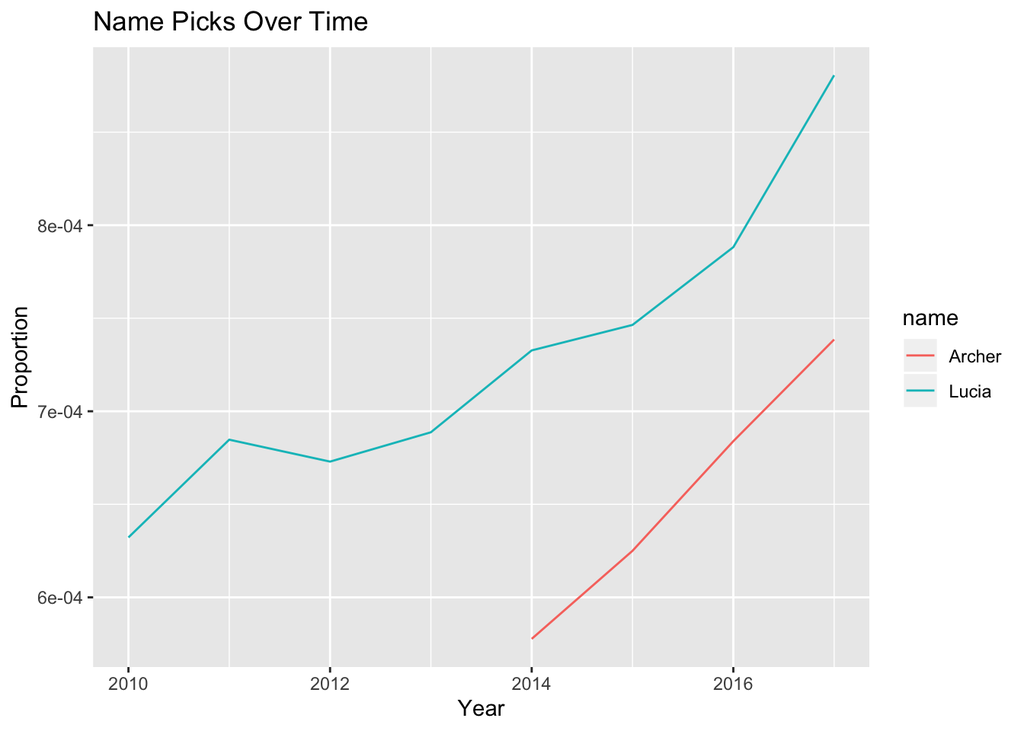

```r
goodnames <- totalbabies %>%
  filter(prop <= .001) %>%
  filter(prop >= .0005) %>%
  filter(year >= 2010)

femaleName <- goodnames %>%
  filter(name == "Lucia", sex == 'F')

maleName <- goodnames %>%
  filter(name == "Archer", sex == "M")

namePick <- full_join(maleName, femaleName)

ggplot(data = namePick) +
  geom_line(mapping = aes(x = year, y = prop, color = name)) +
  labs(title = "Name Picks Over Time", x = "Year", y = "Proportion", size = 10)
```

**Findings:** I picked the two names Lucia for a girl and Archer for a boy. These names, as shown in the graph. Have been on the increase, but aren’t super popular yet so these names are great picks. They should contiune to rise in popularity as seen in the graphs.

## Team Report

**Trent:** In this lab, I did the graph and write up to the Litte Mermaid Effect section by comparing the change in proportions of the name Ariel to the three most popular female names from 1988. I used a geom_smooth plot to showcase this effect. For every name detected in this lab, I used the string dectect feature, and used geom_smooth plots and histograms to compare how proportions of names change over time.

**Tyler:** In this Lab I made my individual plots by filtering out names with strings. I then used the different filtered out portions to make my different plots. For the plots about my names I used bar grabs as it shows the popularity of the name for each year. For my recommendations for baby names I used a line plot to show how both the male and female name were on the rise.

**Logan:** In this Lab, I did the graph for the poularity for “Logan”. I then used different filtered out porsions to make different plots for this popluarity. For my recommendations for baby names I used a line plot to show the names I picked were on the rise of popularity.

**Jack:** In this lab, I created the Little Mermaid Effect graph as well as setting up answers for the main part of the lab’s questions. I made my individual plots by utilizing the string detect function. To find my recommendations for baby names I also utilized string detect and filtered by proportion to find a name that was not popular. From there I checked the proportions for that name to see if the name was on the rise.